# Homework 2

### Exercise 3.5

Consider solving the matrix equation $Ax = y$ for $x$, where $y$ is a known n vector and $A$ is a known $n×n$ matrix. The formal solution to the problem is $x = A^{−1}y$, but it is possible to solve the equation directly, without actually forming $A^{−1}$. This question explores this direct solution. Read the help file for $solve$ before trying it.

1. First create an $A$, $x$ and $y$ satisfying $Ax = y$.

*solution :*

```r
set.seed(0);
n <- 1000
A <- matrix(runif(n*n),n,n);
x.true <- runif(n)
y <- A%*%x.true
```

The idea is to experiment with solving $Ax = y$ for $x$, but with a known truth to compare the answer to.

2. Using solve, form the matrix $A^{−1}$ explicitly and then form $x_1 = A^{−1}y$. Note how long this takes. Also assess the mean absolute difference between $x1$ and $x.true$ (the approximate mean absolute ‘error’ in the solution).

*solution :*

```r
start1 <- Sys.time()
A_inv <- solve(A)
x1 <- A_inv%*%y
end1 <- Sys.time()

naive_time = end1-start1
naive_time
```

```
## Time difference of 0,1957712 secs
```

```r
mean_abs1 <- mean(abs(x1 - x.true))
mean_abs1
```

```
## [1] 2,591911e-11
```

3. Now use solve to directly solve for $x$ without forming $A^{−1}$. Note how long this takes and assess the mean absolute error of the result.

*solution :*

```r
start2 <- Sys.time()
x2 <- solve(A,y)
end2 <- Sys.time()

opt_time = end2-start2
opt_time
```

```
## Time difference of 0,139787 secs
```

```r
mean_abs2 <- mean(abs(x2 - x.true))
mean_abs2
```

```
## [1] 7,68609e-13
```

4. What do you conclude?

*solution :*

By assing the taken time and the mean absolute difference between both solutions, it is given that the average absolute difference using $solve$ function directly is much lesser than using $solve$ with inverse matrix. Also, it takes much less time.

## Data Analysis and Graphics Using R

### CH3.Exercise 11

The following data represent the total number of aberrant crypt foci (abnormal growths in the colon) observed in seven rats that had been administered a single dose of the carcinogen azoxymethane and sacrificed after six weeks (thanks to RanjanaBird, Faculty of Human Ecology, University of Manitoba for the use of these data): 87 53 72 90 78 85 83 Enter these data and compute their sample mean and variance. Is the Poisson model appropriate for these data? To investigate how the sample variance and sample mean differ under the Poisson assumption, repeat the following simulation experiment several times: x <- rpois(7, 78.3) mean(x); var(x)

*solution :*

```r
data <- c(87, 53, 72, 90, 78, 85, 83)
smean = mean(data)
svar = var(data)
smean ; svar
```

```
## [1] 78,28571
```

```
## [1] 159,9048
```

```r
#the variance is almost the double of the mean, may Poisson is not appropriate

times = 100
samples_stat <- as.data.frame(matrix(NA,2,times))
colnames(samples_stat) = c("mean", "variance")

# n = 7; #lambda = 78.3
for (i in 1:times){
  x <- rpois(7, 78.3)
  samples_stat[i,"mean"] = mean(x)
  samples_stat[i,"variance"] = var(x)
}

mean(samples_stat[, "mean"]); mean(samples_stat[ ,"variance"])
```

```
## [1] 78,62143
```

```
## [1] 77,92714
```

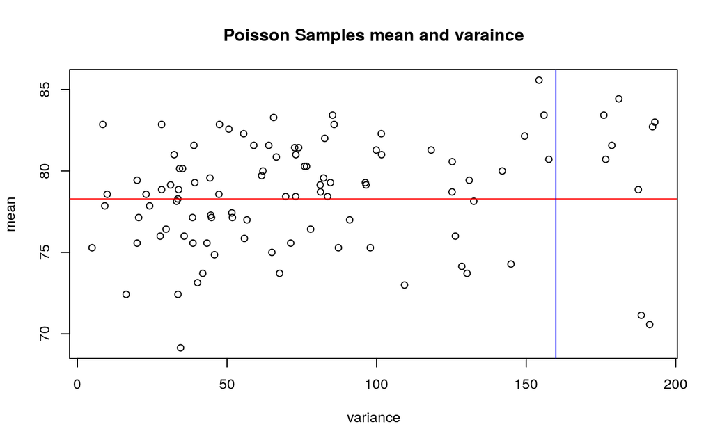

```
## integer(0)
```

```r
plot(samples_stat$variance, samples_stat$mean, ylab = expression(mean), xlab = expression(variance), main = "Poisson Samples mean and varaince") + abline(h = smean , col = "red") + abline(v = svar, col = "blue")
```

We can see that the variance of the given data is significantly larger than the mean (variance is approximately twice of the mean), and after sampling from Poisson distribution multiple times, a few samples variances were close to the variance of the data ,this makes it doubtful that these data are following Poisson distribution. We can conclude that the given data is not enough to decide whether Poisson distribution is appropriate or not.

### CH3.Exercise 13

A Markov chain for the weather in a particular season of the year has the transition matrix, from one day to the next:

$Pb = \begin{bmatrix} & Sun & Cloud & Rain \\ Sun & 0.6 & 0.2 & 0.2 \\ Cloud & 0.2 & 0.4 & 0.4 \\ Rain & 0.4 & 0.3 & 0.3 \end{bmatrix}$

It can be shown, using linear algebra, that in the long run this Markov chain will visit the states according to the stationary distribution: Sun Cloud Rain 0.641 0.208 0.151

A result called the ergodic theorem allows us to estimate this distribution by simulating the Markov chain for a long enough time.

1. Simulate 1000 values, and calculate the proportion of times the chain visits each of the states. Compare the proportions given by the simulation with the above theoretical proportions.

*solution :*

```r
Pb <- matrix(c(0.6, 0.2, 0.2,
                     0.2, 0.4, 0.4,
                     0.4, 0.3, 0.3), nrow = 3, ncol = 3, byrow = TRUE)

Markov = function(R, init, Mat ){
  chain = numeric(R)
  chain[1] = init+1

  for(i in 2:R){
    chain[i] = sample(x = 1:3, size =1, prob = Mat[chain[i-1], ])
  }
  chain - 1

}

results <- table(Markov(R= 1000, init = 0, Mat= Pb))
results
```

```
##
##   0   1   2
## 457 268 275
```

```r
print(results/1000)
```

```
##
##     0     1     2
## 0,457 0,268 0,275
```

```r
#0:Sun, 1:Cloud, 2:rain
```

2. Here is code that calculates rolling averages of the proportions over a number of simulations and plots the result. It uses the function rollmean() from the zoo package. Try varying the number of simulations and the width of the window. How wide a window is needed to get a good sense of the stationary distribution? This series settles down rather quickly to its stationary distribution (it “burns in” quite quickly). A reasonable width of window is, however, needed to give an accurate indication of the stationary distribution.

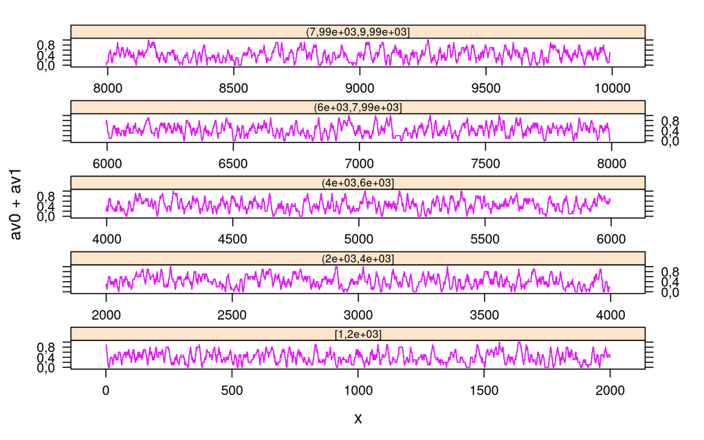

```r
library(zoo)
library(lattice)

plotmarkov <- function(n=10000, start=0, window=100, transition=Pb, npanels=5){
      xc2 <- Markov(n, start, transition)
      mav0 <- rollmean(as.integer(xc2==0), window)
      mav1 <- rollmean(as.integer(xc2==0), window)
      npanel <- cut(1:length(mav0), breaks=seq(from=1, to=length(mav0),
      length=npanels+1), include.lowest=TRUE)
      df <- data.frame(av0=mav0, av1=mav1, x=1:length(mav0),
      gp=npanel)
      print(xyplot(av0+av1 ~ x | gp, data=df, layout=c(1,npanels),
      type="l", par.strip.text=list(cex=0.65),
      scales=list(x=list(relation="free"))))
}
plotmarkov(window = 10)
```

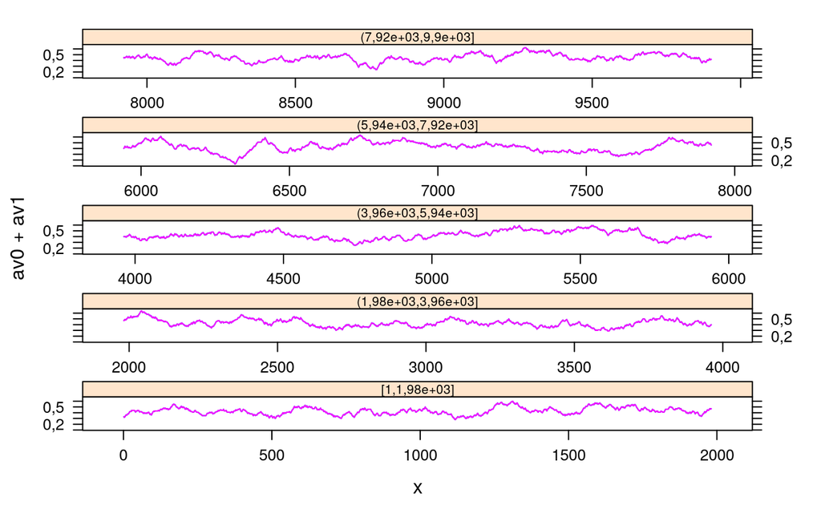

```r
plotmarkov(window = 100)
```

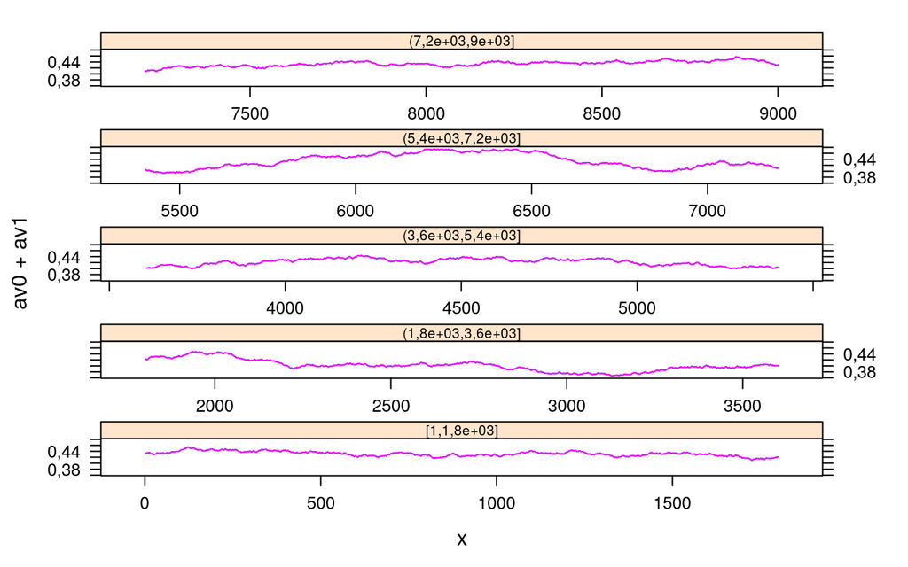

```r
plotmarkov(window = 1000)
```

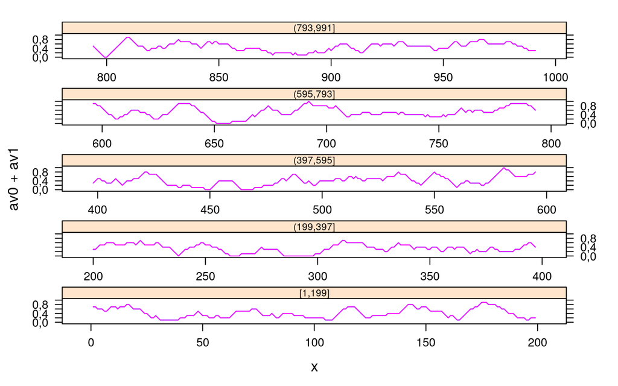

```r
plotmarkov(n=1000, window = 10)
```

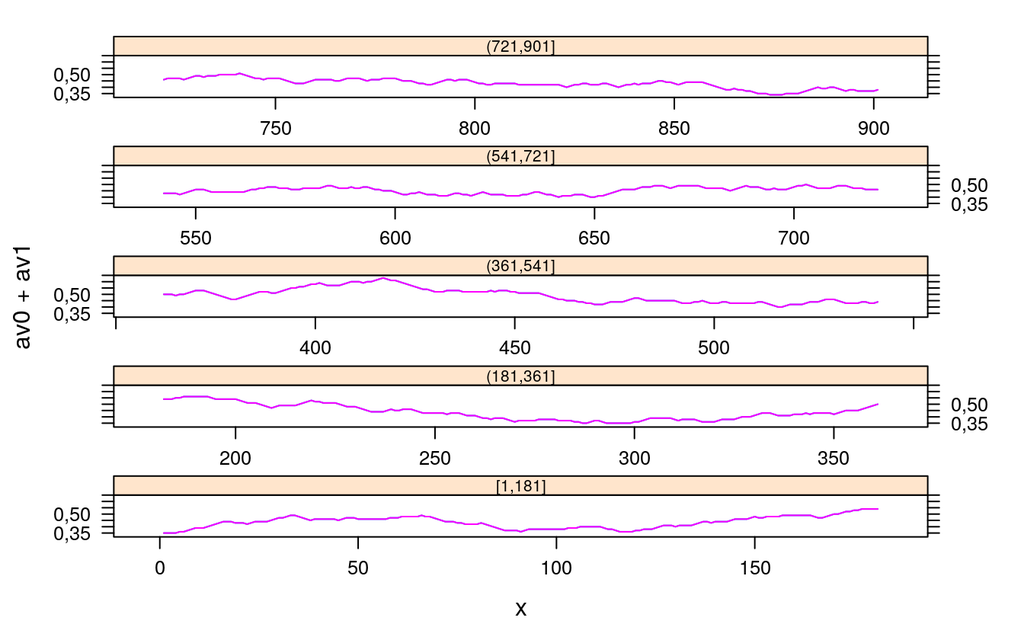

```r
plotmarkov(n=1000, window = 100)
```

```r
#plotmarkov(n=1000, window = 1000) #not working
```

### CH4.Exercise 6

Here we generate random normal numbers with a sequential dependence structure:

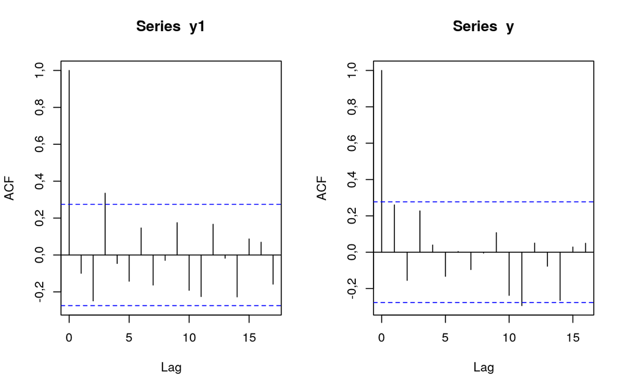

```r
y1 <- rnorm(51)
y <- y1[-1] + y1[-51]
par (mfrow=c(1,2))
acf(y1) # acf is ‘autocorrelation function
acf(y)
```

Repeat this several times. There should be no consistent pattern in the acf plot for different random samples y1. There will be a fairly consistent pattern in the acf plot for y, a result of the correlation that is introduced by adding to each value the next value in the sequence.

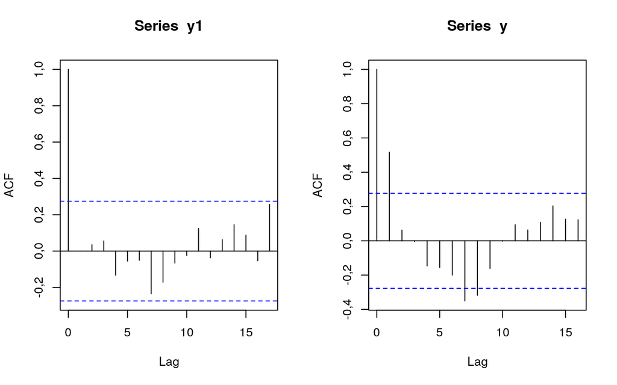

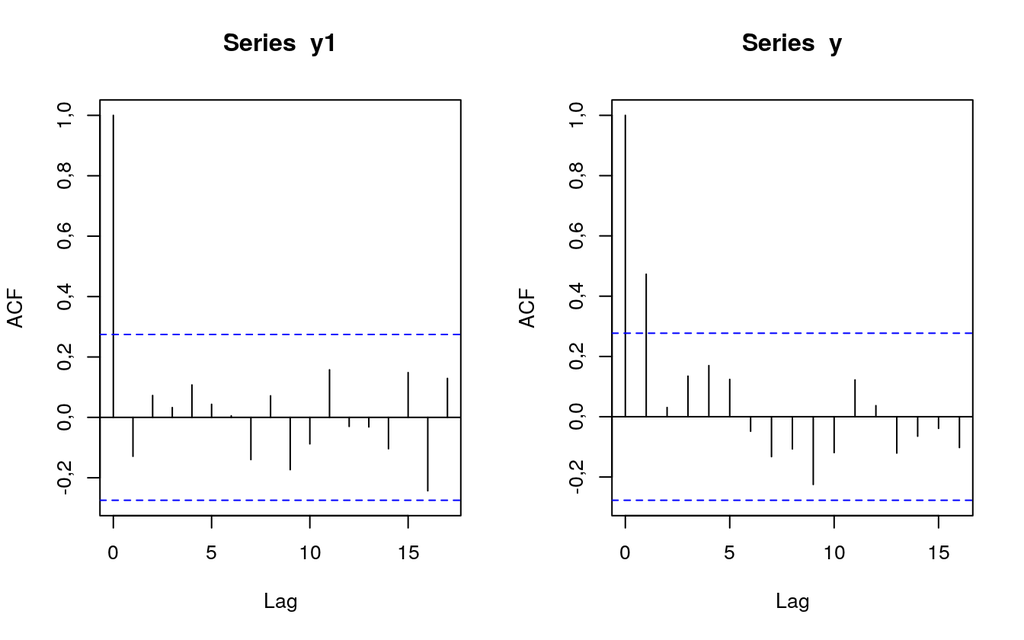

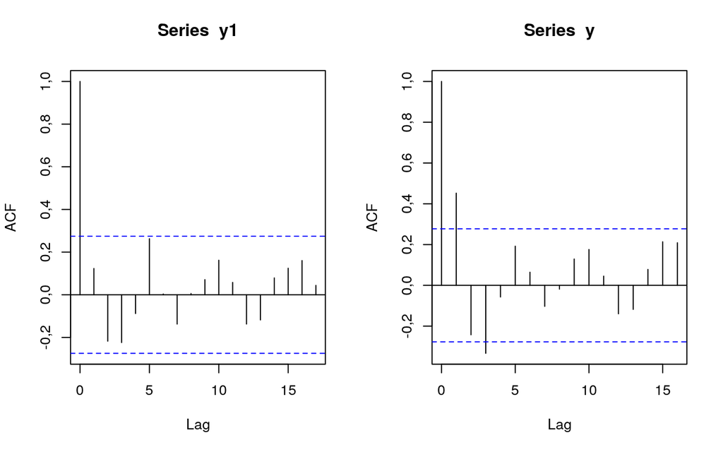

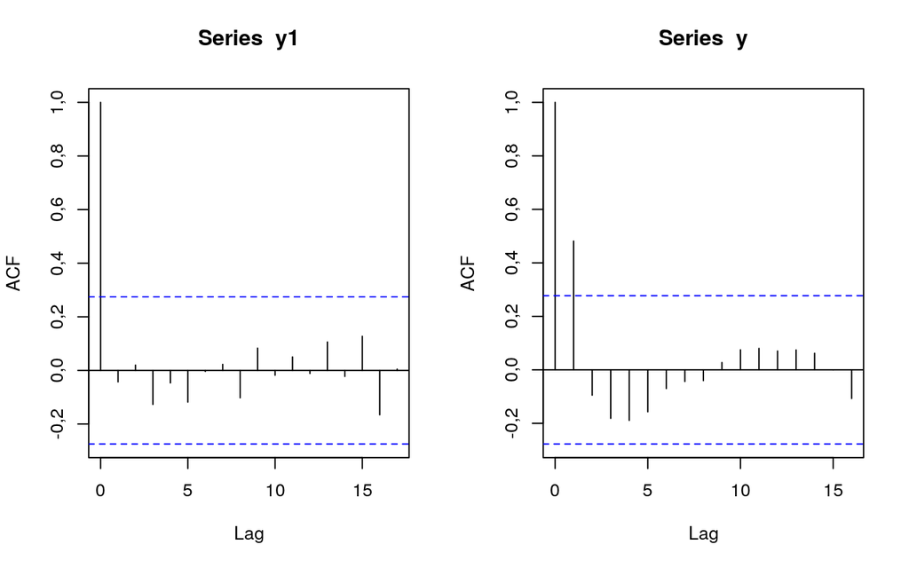

```r
for (i in 1:4) {

    y1 <- rnorm(51)
    y <- y1[-1] + y1[-51]
    par (mfrow=c(1,2))
    acf(y1) # acf is ‘autocorrelation function
    acf(y)
}
```

### CH4.Exercise 7

Create a function that does the calculations in the first two lines of the previous exercise. Put the calculation in a loop that repeats 25 times. Calculate the mean and variance for each vector y that is returned. Store the 25 means in the vector av, and store the 25 variances in the vector v. Calculate the variance of av.

*solution :*

```r
auto_cor <- function(){
  y1 <- rnorm(51) # this is iid
  y <- y1[-1] + y1[-51] #this is not iid, correlated
  y
}
av <- numeric(25)
v <- numeric(25)
for (j in 1:25){
  y <- auto_cor()
  av[j] <- mean(y)
  v[j] <- var(y)
}

var(av)
```

```
## [1] 0,08565732
```

[figure not shown]